# Building a shiny application step by step

# Step 1 :

Build an application, which will ask the user to enter a first name and will display the evolution of its popularity curve

To help you you can start from the template template_app1.R

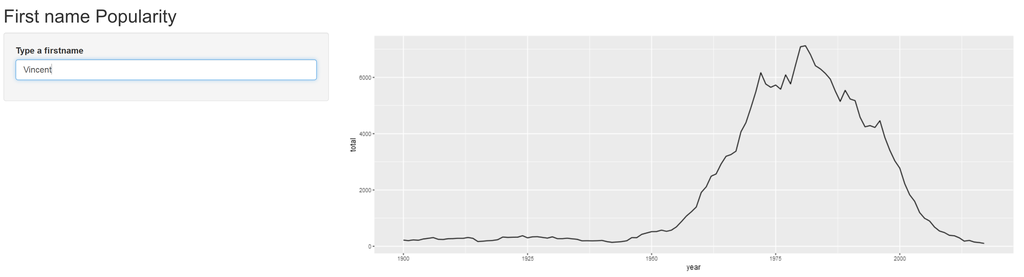

# Step 2 :

Improve the previous application by adding a sentence that indicates the total number of births for the selected first name

You can use the `glue::glue` function to build this sentence

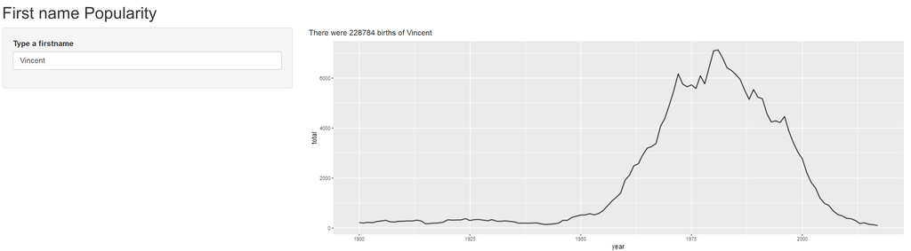

# Step 3 :

Replace the “free” text box with a drop-down menu offering to choose from an existing first name

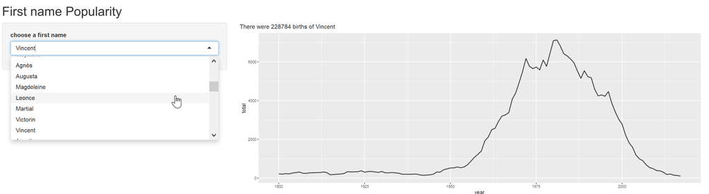

# Step 4 :

Add a drop-down menu proposing to modify the color of the graph plot You can use `palette()` to create a color vector. You may need to edit the `draw_a_name` function by adding a `color`parameter.

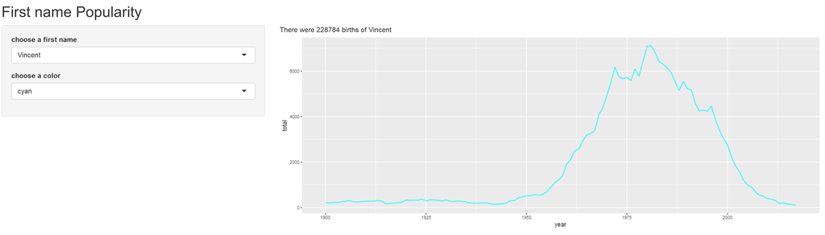

# Step 5 :

Using a “multiple” slider input, ask the user to specify a period for which to draw the graph ( you can use `ggplot2::xlim()` or `ggplot2::coord_cartesian(xlim=)`but these 2 functions don’t do exactly the same thing ). *(If you want you can adjust the sentence reated at step 2)*

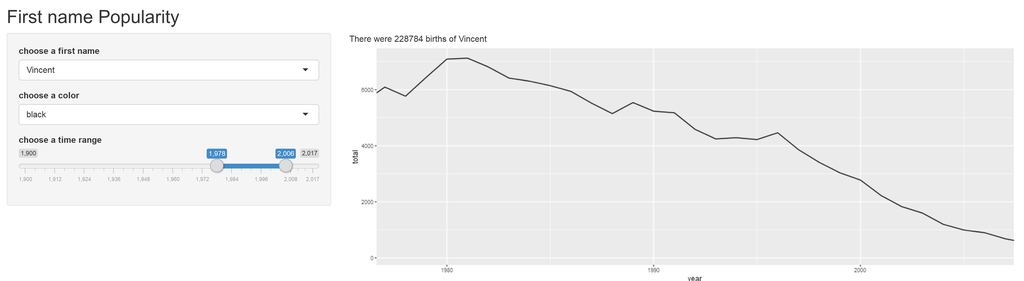

# Step 6 :

Add under the graph the table of births by year for the selected name. Remember to use `reactive` to filter on first name only once

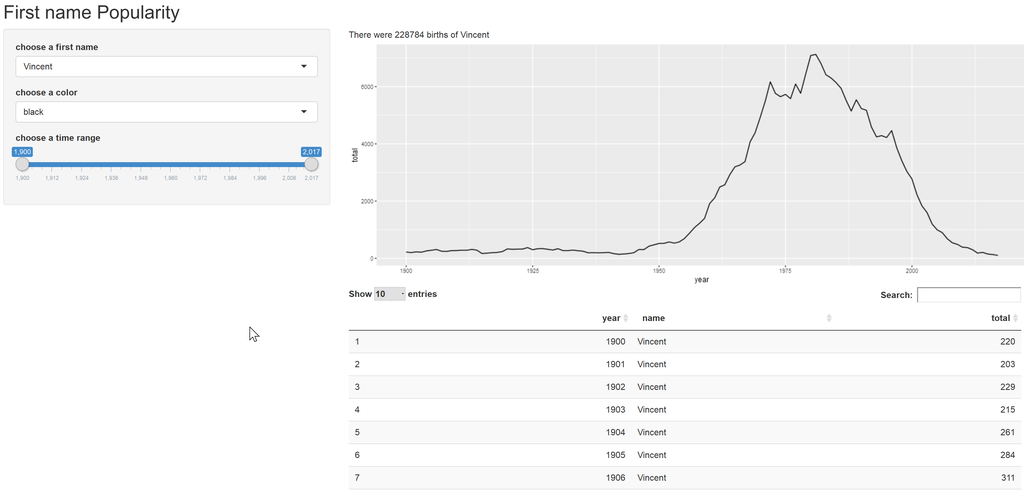

# Step 7

Two checkboxes (girls/boys) must be added to allow to filter (or not) on sex . *(without using `reactive` it could be tricky)*

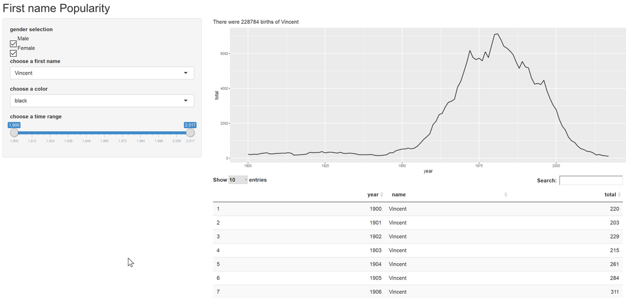

# Step 8

Changing the color of the graph must not regenerate the graph (it will only be regenerated if the slider or name is changed)

# Step 9 :

Now only one press of a button should allow you to modify the graph.

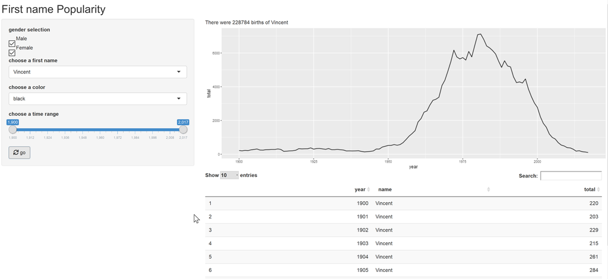

# Step 10:

Although only the button regenerates the graph, set up a log system that indicates that the user is modifying something (by displaying something in the console for example)

# Optimisation

Are you sure you have used optimal approaches in all your previous answers? Make sure, for example, that you do not redo calculations for nothing when you simply change a color -> you have to use as many `reactive` as necessary, cut your code into small pieces to perform a calculation only when it is really necessary.

Does your application take time to display? Isn’t this because you ask the UI part to do a costly calculation (to return all possible names, *especially if you sort the names in alphabetical order*). Try to initialize the `selectInput` choices to `NULL` instead and then edit it with an `updateSelectInput`. The user experience will be greatly improved

Does your application display, even temporarily, error messages in red on the UI side? If so, look at how the `req`, `validate` or `need` functions can help you.

# Step 11:

Edit the IU by adding a tabPanel on it (one tab for graph, one other for the table), Feel free to make it a little prettier.

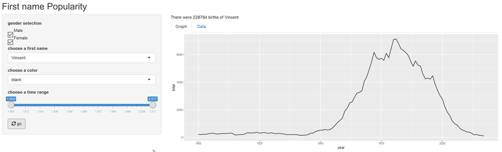

# Step 12:

Create a ShinyModule of your app. You can easily then recall this piece of app in another application

# Step 13:

Create an R package containing your app.

The most ambitious approach is here : https://rtask.thinkr.fr/blog/our-shiny-template-to-design-a-prod-ready-app/

But the quick way is to follow the first 2 steps of this article https://translate.google.fr/translate?hl=fr&sl=auto&tl=en&u=https%3A%2F%2Fthinkr.fr%2Fdockeriser-application-shiny%2F (you dont have to deal with docker here, juste to create an R package)